# BANCseq KdApp Determination

Hannah Neikes

2022-11-29

### This script is an example on how to determine absolute apparent binding affinities (KdApps) in native chromatin by sequencing (BANC-seq).

```r
library(foreach, quietly = T)
library(doParallel, quietly = T)
library(ComplexHeatmap, quietly = T)
library(circlize, quietly = T)
library(RColorBrewer, quietly = T)
```

### 1. Load the data

#### Load a count table of raw counts for each sample at each peak location, as well as information on spike-in reads in each sample.

```r
mm10 <- read.csv('mm10_FLAG_YY1_1000nM_peaks.counts', stringsAsFactors = F, header = T, sep = '\t')
colnames(mm10)[7:ncol(mm10)] <- gsub('X([0-9]{4}_nM_YY1)','\\1',colnames(mm10)[7:ncol(mm10)]) # make sure the column names in this df match with samples names in the spikeIn txt
spikeIn <- read.csv('readCounts_mm10_Yeast_FLAG_YY1.txt', stringsAsFactors = F, header = T, sep = '\t')
spikeIn$spikeIn_yeast <- 1000000/spikeIn$yeast
print(paste("Number of sites before KdApp determination:", nrow(mm10)))
```

```
## [1] "Number of sites before KdApp determination: 22470"
```

```r
print(paste("Number of tested concentrations:", nrow(spikeIn)))
```

```
## [1] "Number of tested concentrations: 9"
```

```r
head(mm10)
```

```
##   Geneid  Chr   Start     End Strand Length 1000_nM_YY1 0564_nM_YY1 0500_nM_YY1
## 1      1 chr1 3670975 3671508      +    534          64          76          55
## 2      2 chr1 3671277 3671810      +    534          77          61          54
## 3      3 chr1 3671727 3672260      +    534          62          47          51
## 4      4 chr1 3672072 3672605      +    534          58          40          46
## 5      5 chr1 3681429 3681962      +    534          29          15          14
## 6      6 chr1 3852231 3852764      +    534          18          15          17
##   0250_nM_YY1 0125_nM_YY1 0050_nM_YY1 0010_nM_YY1 0001_nM_YY1 0000_nM_YY1
## 1          51          21          18          14          10          13
## 2          43          26          23          14          11          11
## 3          29          17          19           9           8          14
## 4          31          13          19           5           8          11
## 5          12           5          15           6          11           6
## 6          15          12          17           1           3           3
```

### 2. Normalisation

#### The following code normalizes reads in each sample to the spike-in DNA, and subsequently calculates the relative binding per tested concentration and site.

```r
mm10_kd <- mm10
for (s in spikeIn$sample) {
  mm10_kd[,s] <- mm10[,s]*spikeIn$spikeIn_yeast[spikeIn$sample == s]
}
mm10_kd$fcOverControl <- log2((mm10_kd$`1000_nM_YY1`+2*sd(mm10_kd$`0000_nM_YY1`))/(mm10_kd$`0000_nM_YY1`+2*sd(mm10_kd$`0000_nM_YY1`))) # fold change of highest concentration over 0 nM sample
mm10_kd[,grep("nM",colnames(mm10_kd))] <- (mm10_kd[,grep("nM",colnames(mm10_kd))]+1)/(mm10_kd$`0000_nM_YY1`+1)
mm10_kd[,grep("nM",colnames(mm10_kd))] <- mm10_kd[,grep("nM",colnames(mm10_kd))]/apply(mm10_kd[,grep("nM",colnames(mm10_kd))],1,max) # relative signal at each binding site for each concentration
head(mm10_kd)
```

```
##   Geneid  Chr   Start     End Strand Length 1000_nM_YY1 0564_nM_YY1 0500_nM_YY1
## 1      1 chr1 3670975 3671508      +    534    0.966694   1.0000000   0.6042279
## 2      2 chr1 3671277 3671810      +    534    1.000000   0.6902142   0.5101113
## 3      3 chr1 3671727 3672260      +    534    1.000000   0.6605065   0.5983055
## 4      4 chr1 3672072 3672605      +    534    1.000000   0.6009474   0.5768908
## 5      5 chr1 3681429 3681962      +    534    1.000000   0.4510472   0.3515890
## 6      6 chr1 3852231 3852764      +    534    1.000000   0.7263133   0.6871863
##   0250_nM_YY1 0125_nM_YY1 0050_nM_YY1 0010_nM_YY1 0001_nM_YY1 0000_nM_YY1
## 1   0.6375952   0.2731234   0.2525032  0.30983136  0.08608027  0.13522254
## 2   0.4622941   0.2906887   0.2773400  0.26641188  0.08138702  0.09843332
## 3   0.3873089   0.2361677   0.2845827  0.21282426  0.07361272  0.15546870
## 4   0.4425319   0.1931478   0.3042008  0.12657373  0.07868732  0.13066514
## 5   0.3429773   0.1490310   0.4802922  0.30348052  0.21598310  0.14286665
## 6   0.6900237   0.5740578   0.8763458  0.08257862  0.09583937  0.11570606
##   fcOverControl
## 1     0.4009686
## 2     0.4929090
## 3     0.3824430
## 4     0.3738932
## 5     0.2002631
## 6     0.1330309
```

### 3. KdApp Determination

#### This is the actual KdApp determination, based on (log10-transformed) concentrations (xValues) and relative binding per peak (yValues).

```r
mm10_kd$kd <- NA
mm10_kd$p <- NA
mm10_kd$r <- NA
mm10_kd$n <- NA
xValues <- c(log10(as.numeric(gsub("([0-9]{4})_nM_YY1","\\1",colnames(mm10_kd[,grep("*nM",colnames(mm10_kd))])))))
xValues <- xValues[xValues >=0]

cl <- makeCluster(10)
registerDoParallel(cl)
ptm <- proc.time()
mm10_kd <- foreach(i=1:nrow(mm10_kd),.combine = rbind,.errorhandling = "remove") %dopar% {
  library(minpack.lm)
  mm10_kdTemp <- mm10_kd[i,]
  yValues <- c(as.numeric(mm10_kd[i,grep("*nM",colnames(mm10_kd[,colnames(mm10_kd) != '0000_nM_YY1']))])) # Don't use the 0nM value!
  myModel <- nlsLM(yValues ~ 1/(((kd/xValues)^n)+1),start = list(kd = 1,n = 1),control = nls.lm.control(maxiter = 50))
  myCoefs <- coef(myModel)
  myCor <- cor.test(yValues,predict(myModel))
  mm10_kdTemp$kd <- 10^(myCoefs[[1]])
  mm10_kdTemp$p <- myCor$p.value
  mm10_kdTemp$r <- myCor$estimate[[1]]
  mm10_kdTemp$n <- myCoefs[[2]]
  mm10_kdTemp
}
stopCluster(cl)
head(mm10_kd)
```

```
##   Geneid  Chr   Start     End Strand Length 1000_nM_YY1 0564_nM_YY1 0500_nM_YY1
## 1      1 chr1 3670975 3671508      +    534    0.966694   1.0000000   0.6042279
## 2      2 chr1 3671277 3671810      +    534    1.000000   0.6902142   0.5101113
## 3      3 chr1 3671727 3672260      +    534    1.000000   0.6605065   0.5983055
## 4      4 chr1 3672072 3672605      +    534    1.000000   0.6009474   0.5768908
## 5      5 chr1 3681429 3681962      +    534    1.000000   0.4510472   0.3515890
## 6      6 chr1 3852231 3852764      +    534    1.000000   0.7263133   0.6871863
##   0250_nM_YY1 0125_nM_YY1 0050_nM_YY1 0010_nM_YY1 0001_nM_YY1 0000_nM_YY1
## 1   0.6375952   0.2731234   0.2525032  0.30983136  0.08608027  0.13522254
## 2   0.4622941   0.2906887   0.2773400  0.26641188  0.08138702  0.09843332
## 3   0.3873089   0.2361677   0.2845827  0.21282426  0.07361272  0.15546870
## 4   0.4425319   0.1931478   0.3042008  0.12657373  0.07868732  0.13066514
## 5   0.3429773   0.1490310   0.4802922  0.30348052  0.21598310  0.14286665
## 6   0.6900237   0.5740578   0.8763458  0.08257862  0.09583937  0.11570606
##   fcOverControl        kd           p         r        n
## 1     0.4009686 174.36680 0.001891538 0.9066907 7.075834
## 2     0.4929090 225.38452 0.003841540 0.8810458 4.727067
## 3     0.3824430 272.16071 0.001310139 0.9176756 6.499369
## 4     0.3738932 279.05862 0.001364914 0.9165191 6.194282
## 5     0.2002631 383.61441 0.207707046 0.4993598 1.537376
## 6     0.1330309  36.16809 0.005221303 0.8677758 2.670069
```

### 4. Select high confidence sites

#### Select sites with high confidence KdApp fit (based on r- and p-value), and remove outliers. For downstream analysis, we also safe the results.

```r
mm10_kd$highConf <- F
mm10_kd$highConf[mm10_kd$p < 0.01 & mm10_kd$r > 0.9] <- T
mm10_kd$outlierMeanSd_n <- F
mm10_kd$outlierMeanSd_kd <- F
my_mean_n <- mean(mm10_kd$n[mm10_kd$highConf])
my_sd_n <- sd(mm10_kd$n[mm10_kd$highConf])
my_up_n <-  my_mean_n+(2*my_sd_n) # Upper Range
my_low_n <- my_mean_n-(2*my_sd_n) # Lower Range
mm10_kd$outlierMeanSd_n[(mm10_kd$n > my_up_n | mm10_kd$n < my_low_n )] <- T
my_mean_kd <- mean(mm10_kd$kd[mm10_kd$highConf])
my_sd_kd <- sd(mm10_kd$kd[mm10_kd$highConf])
my_up_kd <-  my_mean_kd+(2*my_sd_kd) # Upper Range
my_low_kd <- my_mean_kd-(2*my_sd_kd) # Lower Range
mm10_kd$outlierMeanSd_kd[(mm10_kd$kd > my_up_kd | mm10_kd$kd < my_low_kd )] <- T
mm10_kd$outlierMeanSd <- F
mm10_kd$outlierMeanSd[mm10_kd$outlierMeanSd_n == T & mm10_kd$outlierMeanSd_kd != T] <- 'n'
mm10_kd$outlierMeanSd[mm10_kd$outlierMeanSd_n != T & mm10_kd$outlierMeanSd_kd == T] <- 'kd'
mm10_kd$outlierMeanSd[mm10_kd$outlierMeanSd_n == T & mm10_kd$outlierMeanSd_kd == T] <- 'n_kd'
rm(my_low_kd, my_up_kd, my_sd_kd, my_mean_kd, my_mean_n, my_low_n, my_up_n, my_sd_n)

mm10_kd_highConf <- mm10_kd[mm10_kd$highConf == T & mm10_kd$outlierMeanSd != 'n_kd',]
write.table(mm10_kd_highConf, file = 'highConfPeaks_noOutliers.txt', quote = F, col.names = T, row.names = F, sep = '\t')
print(paste("Number of high confidence sites:", nrow(mm10_kd_highConf)))
```

```
## [1] "Number of high confidence sites: 10205"
```

```r
head(mm10_kd_highConf)
```

```
##    Geneid  Chr   Start     End Strand Length 1000_nM_YY1 0564_nM_YY1
## 1       1 chr1 3670975 3671508      +    534   0.9666940   1.0000000
## 3       3 chr1 3671727 3672260      +    534   1.0000000   0.6605065
## 4       4 chr1 3672072 3672605      +    534   1.0000000   0.6009474
## 8       8 chr1 4492613 4493146      +    534   0.9316848   1.0000000
## 9       9 chr1 4493265 4493798      +    534   1.0000000   0.7658913
## 13     13 chr1 4807752 4808285      +    534   1.0000000   0.9170143
##    0500_nM_YY1 0250_nM_YY1 0125_nM_YY1 0050_nM_YY1 0010_nM_YY1 0001_nM_YY1
## 1    0.6042279   0.6375952   0.2731234   0.2525032  0.30983136  0.08608027
## 3    0.5983055   0.3873089   0.2361677   0.2845827  0.21282426  0.07361272
## 4    0.5768908   0.4425319   0.1931478   0.3042008  0.12657373  0.07868732
## 8    0.7501499   0.6472058   0.2435986   0.3089649  0.31690474  0.13257066
## 9    0.7511983   0.7366573   0.2837811   0.3467953  0.06460228  0.10628787
## 13   0.7145244   0.4938274   0.4529814   0.2932666  0.07744753  0.14975085
##    0000_nM_YY1 fcOverControl       kd            p         r        n highConf
## 1    0.1352225     0.4009686 174.3668 0.0018915380 0.9066907 7.075834     TRUE
## 3    0.1554687     0.3824430 272.1607 0.0013101391 0.9176756 6.499369     TRUE
## 4    0.1306651     0.3738932 279.0586 0.0013649143 0.9165191 6.194282     TRUE
## 8    0.1489352     0.3491947 163.4329 0.0012136108 0.9197929 7.383073     TRUE
## 9    0.0832938     0.5747209 138.7901 0.0002744890 0.9515267 5.564925     TRUE
## 13   0.2293404     0.3215770 140.8082 0.0002497142 0.9530494 5.537996     TRUE
##    outlierMeanSd_n outlierMeanSd_kd outlierMeanSd
## 1            FALSE            FALSE         FALSE
## 3            FALSE             TRUE            kd
## 4            FALSE             TRUE            kd
## 8            FALSE            FALSE         FALSE
## 9            FALSE            FALSE         FALSE
## 13           FALSE            FALSE         FALSE
```

### 5. Plot the data

#### To have a quick glance at the KdApps and relative enrichment, we can plot this histogram of KdApps, as well as a Heatmap of the relative enrichment for each site and concentration, alongside the KdApps. The data frame consists of the peak information, relative signal at each site and concentration, as well as KdApps and p- and r-values for the Hill curve fit.

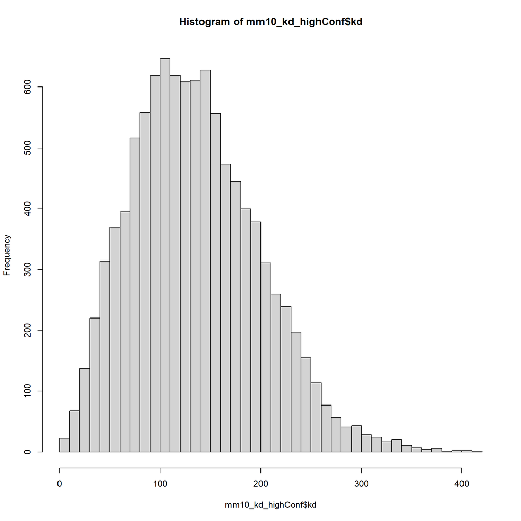

```r
hist(mm10_kd_highConf$kd, breaks = 50)
```

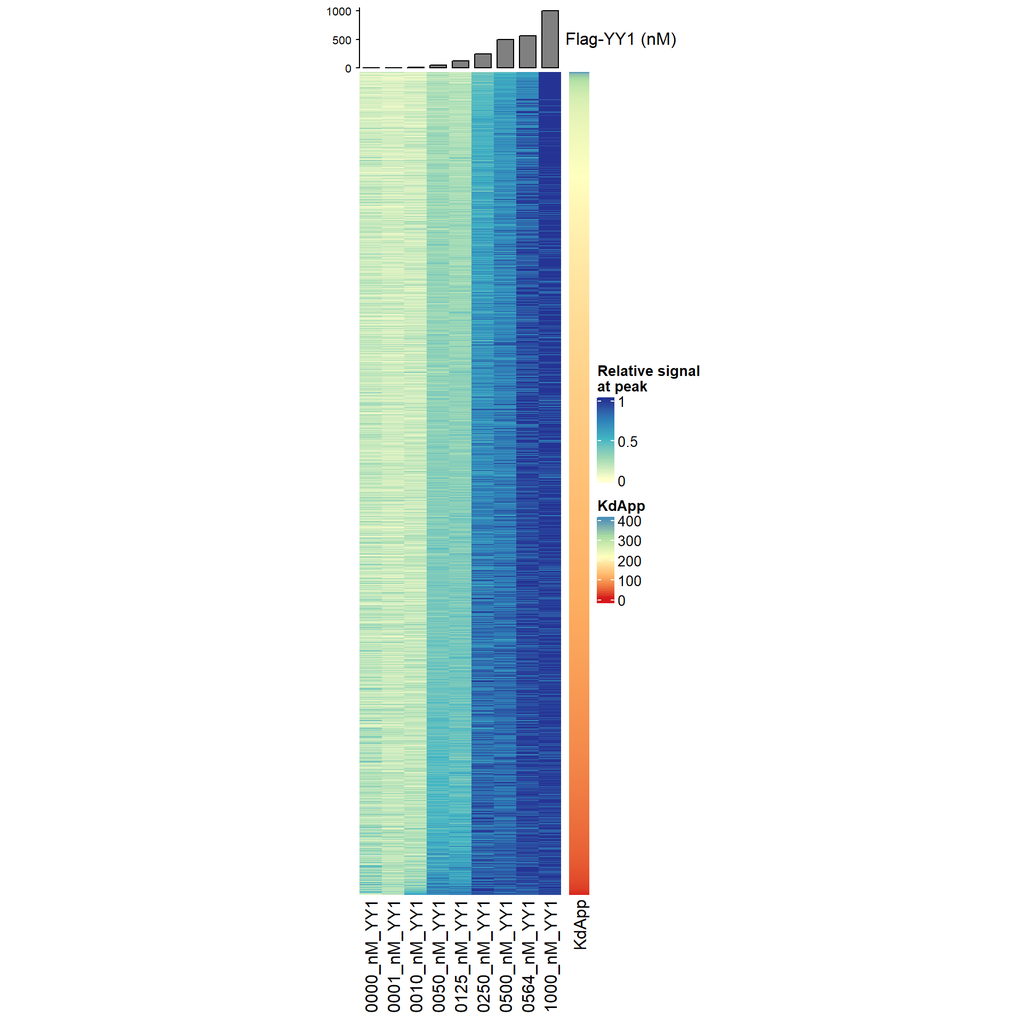

```r
mm10_kd_highConf <- mm10_kd_highConf[order(- mm10_kd_highConf$kd),] # sort the sites by KdApp for visualisation
Heatmap(mm10_kd_highConf[,15:7],
                     cluster_rows = F, cluster_columns = F,
                     name = 'Relative signal\nat peak',
                     width = unit(5, 'cm'),
                     top_annotation = HeatmapAnnotation(
                       'Flag-YY1 (nM)' = anno_barplot(as.numeric(gsub("([0-9]{4})_nM_YY1","\\1",
                                                                      colnames(mm10_kd_highConf[,15:7]))),
                                                      bar_width = 0.75, border = F,
                                                      axis_param = list(side = "left",at = c(0, 500, 1000),
                                                                        labels = c(0, 500, 1000))),
                       height = unit(1.5, 'cm')),
                     col = colorRamp2(breaks = c(0, 0.25, 0.5, 0.75, 1), colors = brewer.pal(5, 'YlGnBu')))+
  Heatmap(mm10_kd_highConf[, 'kd'], name = 'KdApp', width = unit(0.5, 'cm'),
          col = colorRamp2(breaks = c(seq(min(mm10_kd_highConf$kd),max(mm10_kd_highConf$kd),length.out = 5)), brewer.pal(5, 'Spectral')))
```